# act_report

#### When I worked on the Final_df , the first Visualization I did was to find the relation between retweet_count and favorite_count to see if there is any relation between the both of them and I found that both of them have a positive relation and this was realised by visualization using the scatter plot to get the relation between the two variables.

#### The second insight was to compare the conf in p1 ,p2,p3. and after the comparison I found that the always the P1 conf is higher than p2 and p3 . Also the p2 confidence is always higher than p3 .

#### The third insight was to count the number of dogs type from P1 column so i created new column called count to get the count of of each type of the dogs using Final_df['Counts'] = Final_df.groupby(['p1'])['p1'].transform('count') . Then excluded the dogs that have the number of occurances less than twenty . The next step was to draw a histogram to view which dog type has the highest occurance and it is golden retriever and the lowest is the french_bulldog . To get the exact values of the frequency of each dog greater than 20 I used Final_df_dog[Final_df_dog.Counts>20] .

#### The fourth insight was to see the relation between the rating_numerator and the retweet_count. We can see in the visualization that as the rating_numerator increase the retweet_count reaches higher counts. I only used the rating numerator from 0 to 15 as this was my area of interest. I performed the visualization using plt.scatter as the first visualization.

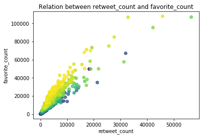

```python
from IPython.display import Image
Image(filename="C:/Users/user/Desktop/Wrangle Project/retweet_fav.png",width=400,height=400)
```

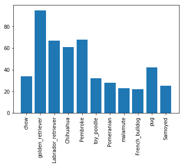

```python
from IPython.display import Image
Image(filename="C:/Users/user/Desktop/Wrangle Project/Dog_count.png",width=400,height=400)
```

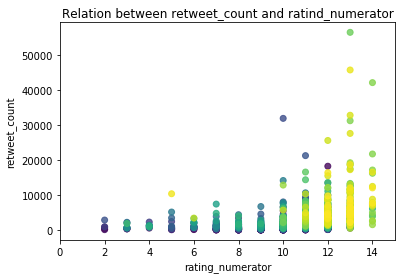

```python
from IPython.display import Image
Image(filename="C:/Users/user/Desktop/Wrangle Project/retweet_numerator.png",width=400,height=400)
```